# Correlation and Regression

## 0.2 **Correlation**

### 0.2.1 Anscombe Data Set

Created by statistician Francis Anscombe in 1973, the data set is used to illustarte concepts of correlation and regression.  
Each set has the same sumamry statistics, correlation, and regression line.  
Correlation coefficient and regression line.the correlation coef in each case here is **0.82**  
Above all, this data set shows the imporatnce of visually inspecting your data.

```r
# load the anscombe data set
Anscombe <- read_csv("Anscombe.csv")
```

As you can see, the sumamry statistics for each set is the same.

```r
# Compute properties of Anscombe
Anscombe %>%
  group_by(Set) %>%
  summarize(N = n(), mean(x), sd(x), mean(y), sd(y), cor(x, y))
```

| Set | N | mean(x) | sd(x) | mean(y) | sd(y) | cor(x, y) |
| --- | --- | --- | --- | --- | --- | --- |
| 1 | 11 | 9 | 3.316625 | 7.500909 | 2.031568 | 0.8164205 |
| 2 | 11 | 9 | 3.316625 | 7.500909 | 2.031657 | 0.8162365 |
| 3 | 11 | 9 | 3.316625 | 7.500000 | 2.030424 | 0.8162867 |
| 4 | 11 | 9 | 3.316625 | 7.500909 | 2.030578 | 0.8165214 |

Let’s take a look at the data.

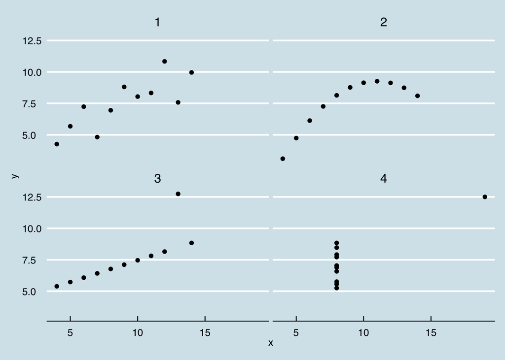

```r
# graph each set
ggplot(data = Anscombe, aes(x = x, y = y)) +
  geom_point() +
  facet_wrap(~ Set) +
  theme_economist()
```

### 0.2.2 Correlation does not imply causation

Correlation is a simple bivariate statistic. Only explains realtionship between two variables. Need to use multiple regression model to get the raltionship between multiple variables.

The proper way to talk about correlation:

- “Counties with lower high school graduation rates are likely to have higher poverty rates.”
- “It may be that a longer gestational period contributes to a heavier birthweight among babies, but a randomized, controlled experiment is needed to confirm this observation.”
- “These data suggest that babies with longer gestational periods tend to be heavier at birth, but there are many potential confounding factors that were not taken into account.”
- There are many potential confounders that can cloud our ability to determine casue and effect.
- Correlations are called **spurious**.
- Time can be a confounder between two variables.

## 0.3 **Regression**

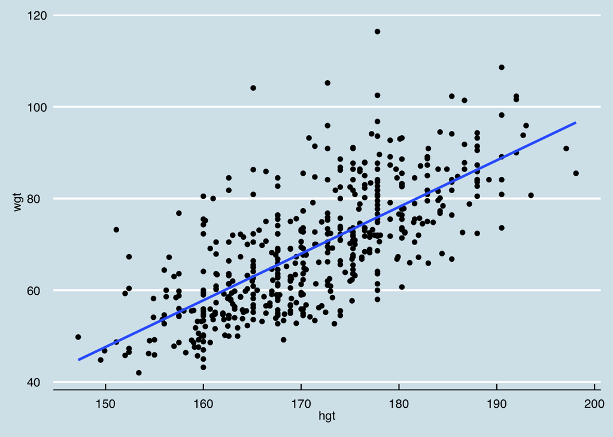

```r
# Scatterplot with regression line
ggplot(data = bdims, aes(x = hgt, y = wgt)) +
  geom_point() +
  geom_smooth(method = "lm", se = FALSE) +
  theme_economist()
```

Response = f(explanatory) + noise In a regression model, we specify that the distribution of the noise is normal with mean 0 and a fixed standard deviation.  
The residuals are the realization of the noise term.  
e = y - y(hat)  
Residuals sum to zero.  
Regression slope and correlation coef are closely related  
**Key Concepts** y-hat is the expected vale given what we know about x Noise is a better term than error.

**Linear Regression Model** takes the form:

*Y=β0+β1⋅X+ϵ, where ϵ∼N(0,σϵ)*

β1 is the slope coefficient

**Regression model output terminology**

The fitted model for the poverty rate of U.S. counties as a function of high school graduation rate is:

**povertyˆ=64.594−0.591⋅hs_grad**

In Hampshire County in western Massachusetts, the high school graduation rate is 92.4%. These two facts imply that the poverty rate in Hampshire County is … ~expected to be about 10.0%.~

**Fitting a linear model “by hand”** Recall the simple linear regression model:  
Y=b0+b1⋅X  
Two facts enable you to compute the slope b1 and intercept b0 of a simple linear regression model from some basic summary statistics.

First, the slope can be defined as:

b1=rX,Y⋅sYsX  
where rX,Y represents the correlation (cor()) of X and Y and sX and sY represent the standard deviation (sd()) of X and Y, respectively.

Second, the point (x¯,y¯) is always on the least squares regression line, where x¯ and y¯ denote the average of x and y, respectively.

Regression models combine some explanatory variables into an estimate for a single numerical response variable.

## 0.4 **Regression to the Mean**

Regression to the mean is a concept attributed to Sir Francis Galton. The basic idea is that extreme random observations will tend to be less extreme upon a second trial. This is simply due to chance alone. While “regression to the mean” and “linear regression” are not the same thing, we will examine them together in this exercise.

One way to see the effects of regression to the mean is to compare the heights of parents to their children’s heights. While it is true that tall mothers and fathers tend to have tall children, those children tend to be less tall than their parents, relative to average. That is, fathers who are 3 inches taller than the average father tend to have children who may be taller than average, but by less than 3 inches.

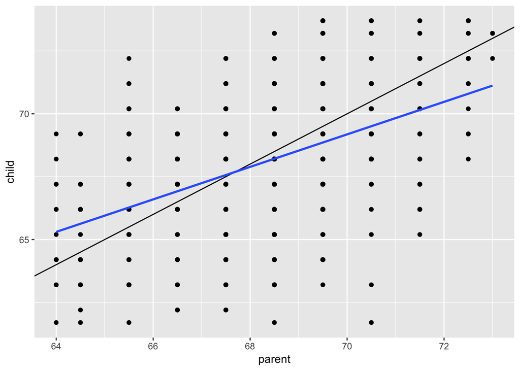

```r
library(HistData)
data(Galton)

# Height of children vs. height of father
ggplot(data = Galton, aes(x = parent, y = child)) +
  geom_point() +
  geom_abline(slope = 1, intercept = 0) +
  geom_smooth(method = "lm", se = FALSE)
```

In an opinion piece about nepotism [published in The New York Times](http://www.nytimes.com/2015/03/22/opinion/sunday/seth-stephens-davidowitz-just-how-nepotistic-are-we.html) in 2015, economist Seth Stephens-Davidowitz wrote that:

> “Regression to the mean is so powerful that once-in-a-generation talent basically never sires once-in-a-generation talent. It explains why Michael Jordan’s sons were middling college basketball players and Jakob Dylan wrote two good songs. It is why there are no American parent-child pairs among Hall of Fame players in any major professional sports league.”

### 0.4.1 **Regression Coefficients & Fitting Regression Models**

Recall that the fitted model for the poverty rate of U.S. counties as a function of high school graduation rate is:

povertyˆ=64.594−0.591⋅hs_grad  
Which of the following is the correct interpretation of the slope coefficient?

*Among U.S. counties, each additional percentage point increase in the high school graduation rate is associated with about a 0.591 percentage point decrease in the poverty rate.*

**Fitting simple linear models** While the geom_smooth(method = “lm”) function is useful for drawing linear models on a scatterplot, it doesn’t actually return the characteristics of the model. As suggested by that syntax, however, **the function that creates linear models is lm()**. This function generally takes two arguments:

- A formula that specifies the model
- A data argument for the data frame that contains the data you want to use to fit the model

The lm() function return a model object having class “lm”. This object contains lots of information about your regression model, *including the data used to fit the model, the specification of the model, the fitted values and residuals, etc.*

```r
# Linear model for weight as a function of height - the first input is the dependent variable(wgt)
lm(wgt ~ hgt, data = bdims)
```

```
##
## Call:
## lm(formula = wgt ~ hgt, data = bdims)
##
## Coefficients:
## (Intercept)          hgt
##    -105.011        1.018
```

```r
# Linear model for SLG as a function of OBP
lm(SLG ~ OBP, data = mlbBat10)
```

```
##
## Call:
## lm(formula = SLG ~ OBP, data = mlbBat10)
##
## Coefficients:
## (Intercept)          OBP
##    0.009407     1.110323
```

```r
# Log-linear model for body weight as a function of brain weight
lm(log(BodyWt) ~ log(BrainWt), data = mammals)
```

```
##
## Call:
## lm(formula = log(BodyWt) ~ log(BrainWt), data = mammals)
##
## Coefficients:
##  (Intercept)  log(BrainWt)
##       -2.509         1.225
```

The first two regression models can be represented by the following formulas:

wgtˆ=−105.011+1.018⋅hgt and SLGˆ=0.009+1.110⋅OBP

### 0.4.2 The linear model object

The output of the lm() is an object and there is alot you can do with it!  
After we assign the linear model to a model object, mod, we can use the coef() and summary() functions to extract more information.

```r
mod <- lm(wgt ~ hgt, data = bdims)

# Show the coefficients
coef(mod)
```

```
## (Intercept)         hgt
## -105.011254    1.017617
```

```r
# Show the full output
summary(mod)
```

```
##
## Call:
## lm(formula = wgt ~ hgt, data = bdims)
##
## Residuals:
##     Min      1Q  Median      3Q     Max
## -18.743  -6.402  -1.231   5.059  41.103
##
## Coefficients:
##               Estimate Std. Error t value Pr(>|t|)
## (Intercept) -105.01125    7.53941  -13.93   <2e-16 ***
## hgt            1.01762    0.04399   23.14   <2e-16 ***
## ---
## Signif. codes:  0 '***' 0.001 '**' 0.01 '*' 0.05 '.' 0.1 ' ' 1
##
## Residual standard error: 9.308 on 505 degrees of freedom
## Multiple R-squared:  0.5145, Adjusted R-squared:  0.5136
## F-statistic: 535.2 on 1 and 505 DF,  p-value: < 2.2e-16
```

Confirm that the mean of the body weights equals the mean of the fitted values of mod.  
Compute the mean of the residuals of mod.

```r
# Mean of weights equal to mean of fitted values?
mean(bdims$wgt) == mean(fitted.values(mod))
```

```
## [1] TRUE
```

```r
# Mean of the residuals
mean(residuals(mod))
```

```
## [1] -1.266971e-15
```

As you fit a regression model, there are some quantities (e.g. R2) that apply to the model as a whole, while others apply to each observation (e.g. ŷ i). If there are several of these per-observation quantities, it is sometimes convenient to attach them to the original data as new variables.

The **augment()** function from the broom package does exactly this. It takes a model object as an argument and returns a data frame that contains the data on which the model was fit, along with several quantities specific to the regression model, including the fitted values, residuals, leverage scores, and standardized residuals.

```r
# Load broom
library(broom)

# Create bdims_tidy
bdims_tidy <- augment(mod)

# Glimpse the resulting data frame
glimpse(bdims_tidy)
```

```
## Observations: 507
## Variables: 9
## $ wgt        <dbl> 65.6, 71.8, 80.7, 72.6, 78.8, 74.8, 86.4, 78.4, 62.0,…
## $ hgt        <dbl> 174.0, 175.3, 193.5, 186.5, 187.2, 181.5, 184.0, 184.…
## $ .fitted    <dbl> 72.05406, 73.37697, 91.89759, 84.77427, 85.48661, 79.…
## $ .se.fit    <dbl> 0.4320546, 0.4520060, 1.0667332, 0.7919264, 0.8183471…
## $ .resid     <dbl> -6.4540648, -1.5769666, -11.1975919, -12.1742745, -6.…
## $ .hat       <dbl> 0.002154570, 0.002358152, 0.013133942, 0.007238576, 0…
## $ .sigma     <dbl> 9.312824, 9.317005, 9.303732, 9.301360, 9.312471, 9.3…
## $ .cooksd    <dbl> 5.201807e-04, 3.400330e-05, 9.758463e-03, 6.282074e-0…
## $ .std.resid <dbl> -0.69413418, -0.16961994, -1.21098084, -1.31269063, -…
```

### 0.4.3 Making Predictions

The fitted.values() function or the augment()-ed data frame provides us with the fitted values for the observations that were in the original data. However, once we have fit the model, we may want to compute expected values for observations that were not present in the data on which the model was fit. These types of predictions are called out-of-sample.

The ben data frame contains a height and weight observation for one person. The mod object contains the fitted model for weight as a function of height for the observations in the bdims dataset. We can use the predict() function to generate expected values for the weight of new individuals. We must pass the data frame of new observations through the newdata argument.

```r
# create a new dataframe
wgt <- 74.8
hgt <- 182.8

ben <- data.frame(wgt, hgt)

# Print ben
ben
```

| wgt | hgt |
| --- | --- |
| 74.8 | 182.8 |

```r
# Predict the weight of ben
predict(mod, newdata = ben)
```

```
##        1
## 81.00909
```

The geom_smooth() function makes it easy to add a simple linear regression line to a scatterplot of the corresponding variables. And in fact, there are more complicated regression models that can be visualized in the data space with geom_smooth(). However, there may still be times when we will want to add regression lines to our scatterplot manually. To do this, we will use the geom_abline() function, which takes slope and intercept arguments. Naturally, we have to compute those values ahead of time, but we already saw how to do this (e.g. using coef()).

The coefs data frame contains the model estimates retrieved from coef(). Passing this to geom_abline() as the data argument will enable you to draw a straight line on your scatterplot.

```r
# Add the line to the scatterplot
coefs <- data.frame(coef(mod))

# ggplot(data = bdims, aes(x = hgt, y = wgt)) +
#   geom_point() +
#   geom_abline(data = coefs,
#               aes(intercept = `(Intercept)`, slope = hgt),
#               color = "dodgerblue")
```

## 0.5 Residuals and Assessing Model Fit

RMSE - root mean squared error - also, residual standard error - RSE  
R displays this value when you get the summary of the the mod object  
Example - if the value is 3.57 for mod_possum, that is saying that the model generally predicts a value within 3.57cm from the truth.

### 0.5.1 Standard Error of Residuals

One way to assess strength of fit is to consider how far off the model is for a typical case. That is, for some observations, the fitted value will be very close to the actual value, while for others it will not. The magnitude of a typical residual can give us a sense of generally how close our estimates are.

However, recall that some of the residuals are positive, while others are negative. In fact, it is guaranteed by the least squares fitting procedure that the mean of the residuals is zero. Thus, it makes more sense to compute the square root of the mean squared residual, or root mean squared error (RMSE). R calls this quantity the residual standard error.

To make this estimate unbiased, you have to divide the sum of the squared residuals by the degrees of freedom in the model.  
**You can recover the residuals from mod with residuals(), and the degrees of freedom with df.residual().**